# Orbits.R

georg

Wed Dec 21 21:25:28 2016

These simulations use Hamiltonian dynamics to approximate the the behaviour of a particle in various conservative fields including a field whose potential has banana-shaped contours.

## Parametric family of banana distributions

These distributions are generated by transforming a bivariate normal variate $\left( {\begin{array}{*{20}{c}} x \\ y \end{array}} \right)$, centered at the origin with the transformation:
$$\left( {\begin{array}{*{20}{c}}
{x'} \\
{y'}
\end{array}} \right) = \left( {\begin{array}{*{20}{c}}
x \\
{y + a{x^2}}
\end{array}} \right)$$
and then rotating the result counterclockwise through an angle $\phi$.

Both of these transformations have unit Jacobian determinants so that the density contours are transformed though the same transformation.

The following functions implement these transformations.

Note that $Rot^{-1}(.,\phi) = Rot(.,-\phi)$ and $Tr^{-1}(.,a) = Tr(.,-a)$

## Rotation in $R^2$

```r
Rot <- function(x, phi) {
  # Counterclockwise rotation in R2 by phi radians
  as.vector(cbind(c(cos(phi), sin(phi)), c(-sin(phi), cos(phi))) %*% as.vector(x))
}
Rot_jac <- function(x, phi)  cbind(c(cos(phi), sin(phi)), c(-sin(phi), cos(phi)))
Rot_inv <- function(y, phi) Rot(y, -phi)
Rot_inv_jac <- function(y, phi) Rot_jac(y, -phi)
```

## Quadratic transformation

A transformation with a unit Jacobian determinant that turns a horizontally stretched ellipse into a ‘smile’

```r
Tr <- function(x, a) c(x[1], x[2] + a * x[1]^2)
Tr_jac <- function(x, a) cbind(c(1, 2*a*x[1]), c(0,1))
Tr_inv <- function(y, a) Tr(y, -a)
Tr_inv_jac <- function(y, a) Tr_jac(y, -a)
```

To use HMC we need the negative of the log density function and its gradient. To visualize the trajectories, We also wish to have a function to generate contours of the density function.

Note that $a = 0$ produces a normal densities centered at 0.

```r
f_gen <- function(phi, a, Sigma) function(x) {
  # negative of log of density
  # using the fact that Tr and Rot have unit jacobien determinants
  - dmvnorm(Tr_inv(Rot_inv(x, phi), a), sigma = Sigma, log = TRUE)
}
f_grad_gen <- function(phi, a, Sigma) function(x) {
  # gradient of f
  x1 <- Rot_inv(x, phi)
  x2 <- Tr_inv(x1, a)
  c(t(Rot_inv_jac(x, phi)) %*% t(Tr_inv_jac(x1, a)) %*% solve(Sigma, x2))
}
f_contour_gen <- function(phi, a, Sigma) function(deviance = 1, n = 100) {
  # With unit jacobian determinants, the contour of the density of
  # the transformation is the transformation of the contour of the density
  e <- spida2::ell(c(0,0), radius = sqrt(deviance), shape = Sigma, n = n)
  e2 <- apply(e, 1, Tr, a)
  t(apply(e2, 2, Rot, phi))
}
```

### Generating f, fg and fc

```r
phi <- pi/3
a <- 0.03
Sigma <- cbind( c(36,0),c(0,1))
f <- f_gen(phi, a, Sigma)
fg <- f_grad_gen(phi, a, Sigma)
fc <- f_contour_gen(phi, a, Sigma)



hamTraj <- function(x0, m0, neglogf, grad, stepsize=1, steps=20, verbose = FALSE){
  # Hamiltonian trajectory with leapfrog
  xmat <- matrix(NA,steps+1,length(x0))
  mmat <- matrix(NA,steps+2,length(x0))
  xmat[1, ] <- x <- x0
  mmat[1, ] <- mom <- m0
  mmat[2, ] <- mom <- mom - 0.5*stepsize*grad(x0)  # half-step for momentum
  for (step in 1:(steps - 1)){
    xmat[step+1, ] <- x <- x + stepsize*mom
    mmat[step+2, ] <- mom <- mom - stepsize*grad(x)
  }
  xmat[steps + 1, ] <- x <- x + stepsize*mom # last step for position
  mmat[steps + 2, ] <- mom <- mom  - 0.5 * stepsize * grad(x)  # last half-step for momentum
  a <- exp(neglogf(x0) - neglogf(x) + 0.5*sum(m0^2) - 0.5*sum(mom^2))
  p <- runif(1)
  move <- p < a
  list(x = xmat, m = mmat, a = a , p = p, move = move)
}
```

Trajectory using a stepsize of 0.01

```r
# initialize

par(bg='white')
  plot(fc(c(.001,seq(1,6)^2)),type = 'l', lty = 2, ylim = c(-15,50), xlim=c(-50,15), asp = 1, xlab = '',ylab = '')
```

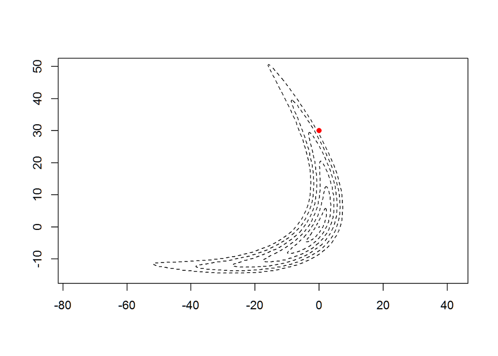

```r
  stepsize <- 0.01
  steps <- 200
  pch <- 16
  cex = 1
  col  <- 'red'

  x <- c(0,30)
  m <- c(0,0)

  points( rbind(x), pch = 16, col = 'red')
```

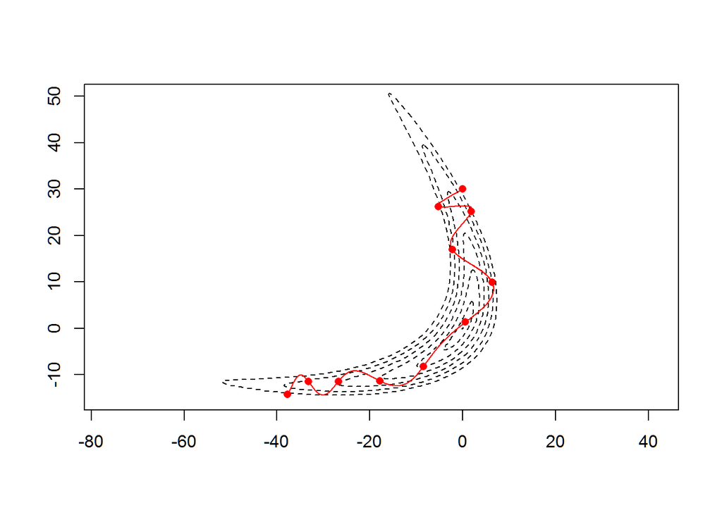

```r
  ac <- 0
  for(i in 1:10) {
    ret <- hamTraj(x,m, f, fg, stepsize = stepsize, steps = steps)
    lines(ret$x,col=col)
    ac <- ac + (ret$a-1)^2
    points(tail(ret$x,1), pch = pch, col = col)
    x <- c(tail(ret$x,1))
    m <- c(tail(ret$m,1))
  }
```

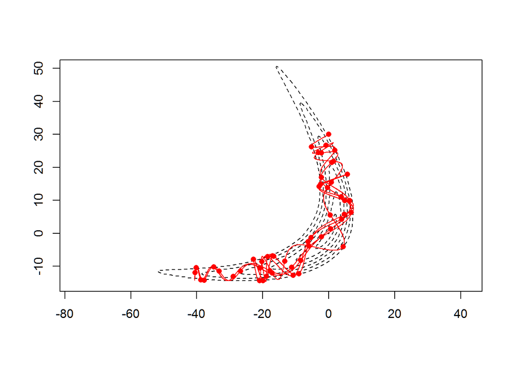

```r
  for(i in 11:50) {
    ret <- hamTraj(x,m, f, fg, stepsize = stepsize, steps = steps)
    lines(ret$x,col=col)
    ac <- ac + (ret$a-1)^2
    points(tail(ret$x,1), pch = pch, col = col)
    x <- c(tail(ret$x,1))
    m <- c(tail(ret$m,1))
  }
```

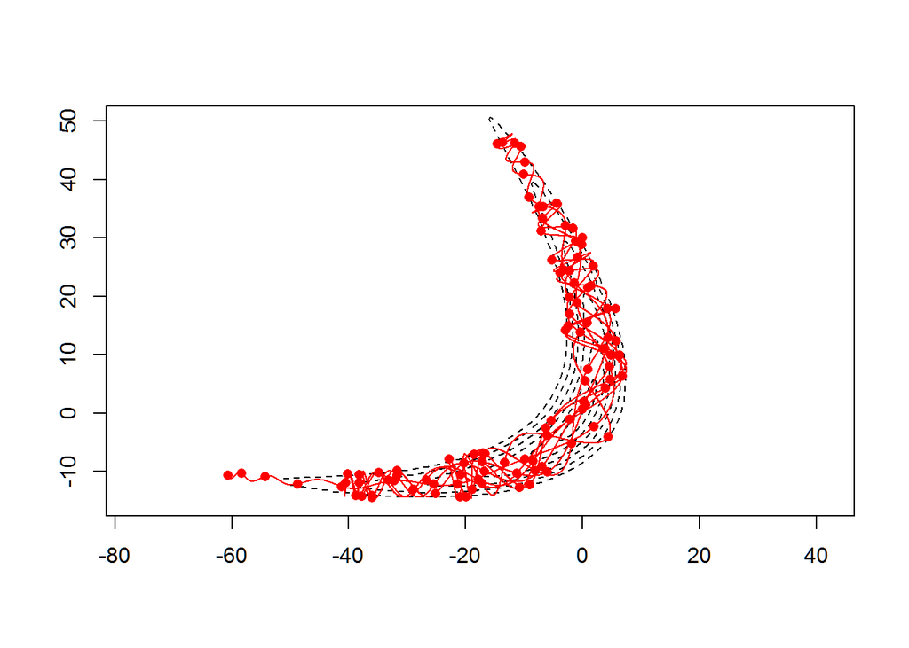

```r
  for(i in 51:100) {
    ret <- hamTraj(x,m, f, fg, stepsize = stepsize, steps = steps)
    lines(ret$x,col=col)
    ac <- ac + (ret$a-1)^2
    points(tail(ret$x,1), pch = pch, col = col)
    x <- c(tail(ret$x,1))
    m <- c(tail(ret$m,1))
  }
```

```r
  cat("Cumulative squared energy disparity:", ac,'\n' )
```

```
## Cumulative squared energy disparity: 8.489217e-06
```

Note that the particle seems to escape at the end, or, at least, achieves a higher energy than its initial energy.

Repeat with smaller stepsize

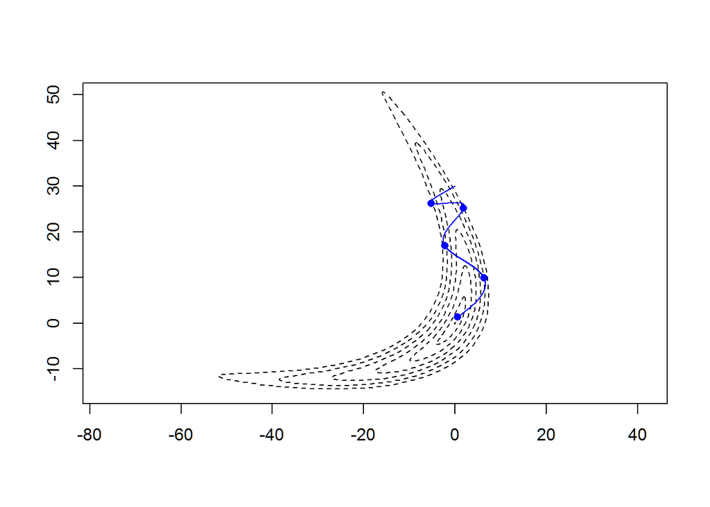

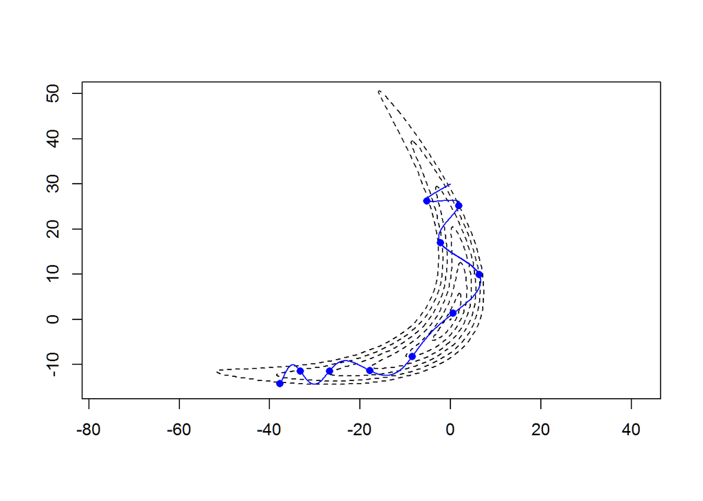

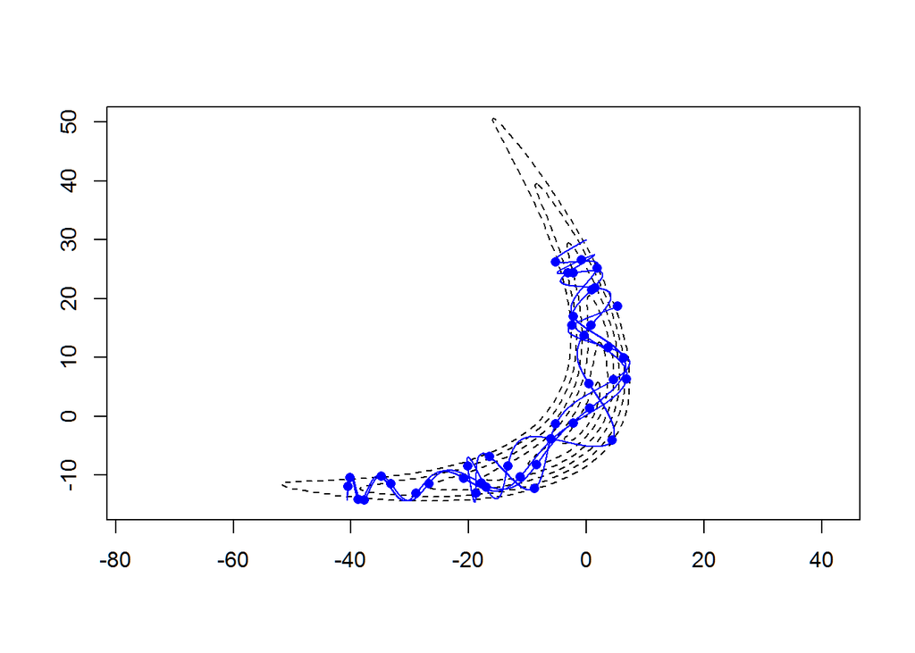

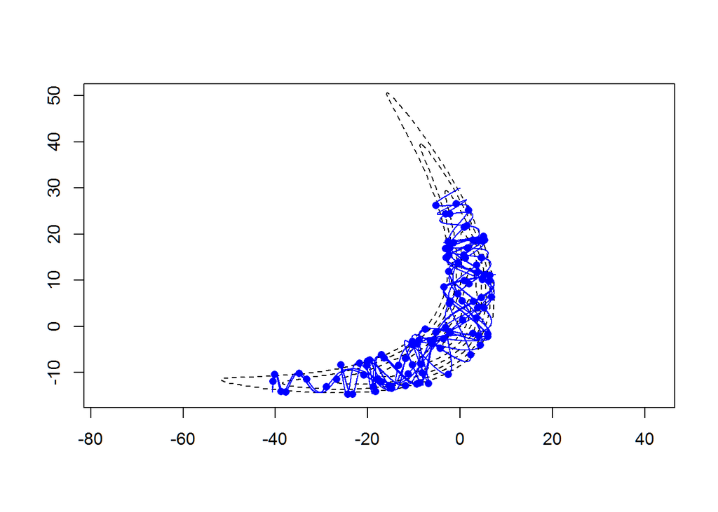

```
## Cumulative squared energy disparity: 1.161306e-09
```

There was no escape this time.

Repeating with larger stepsize

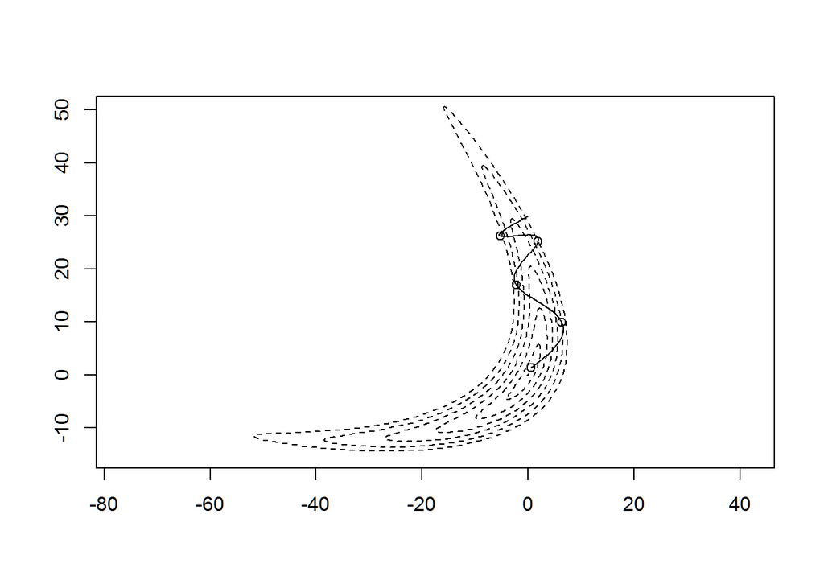

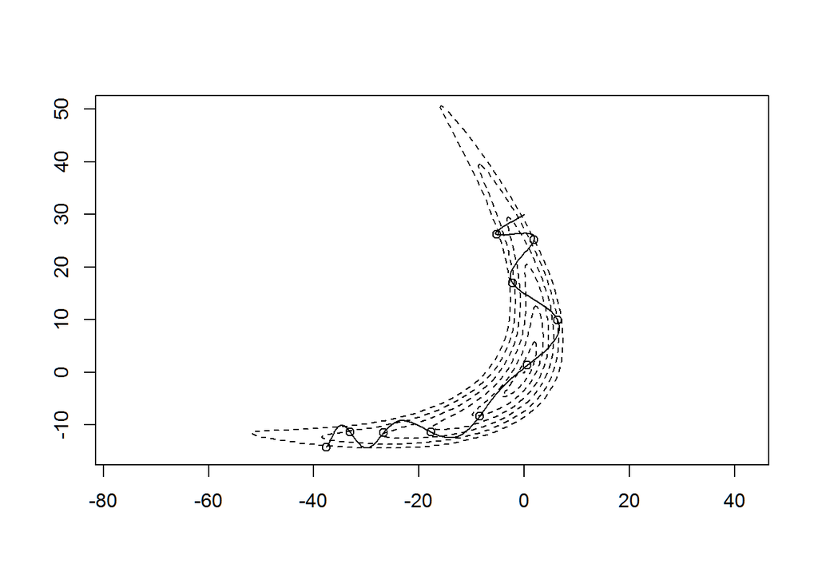

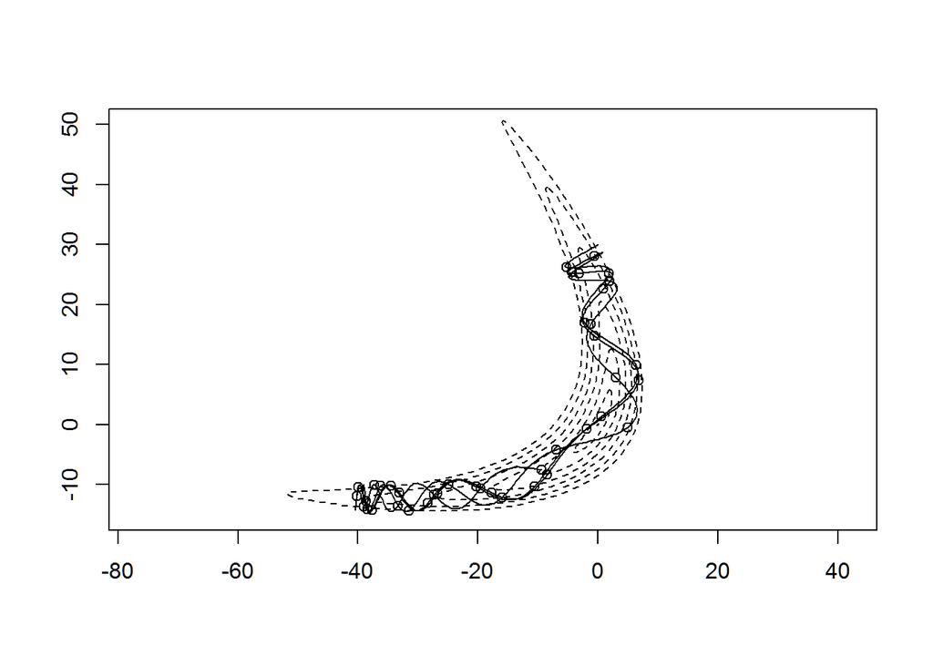

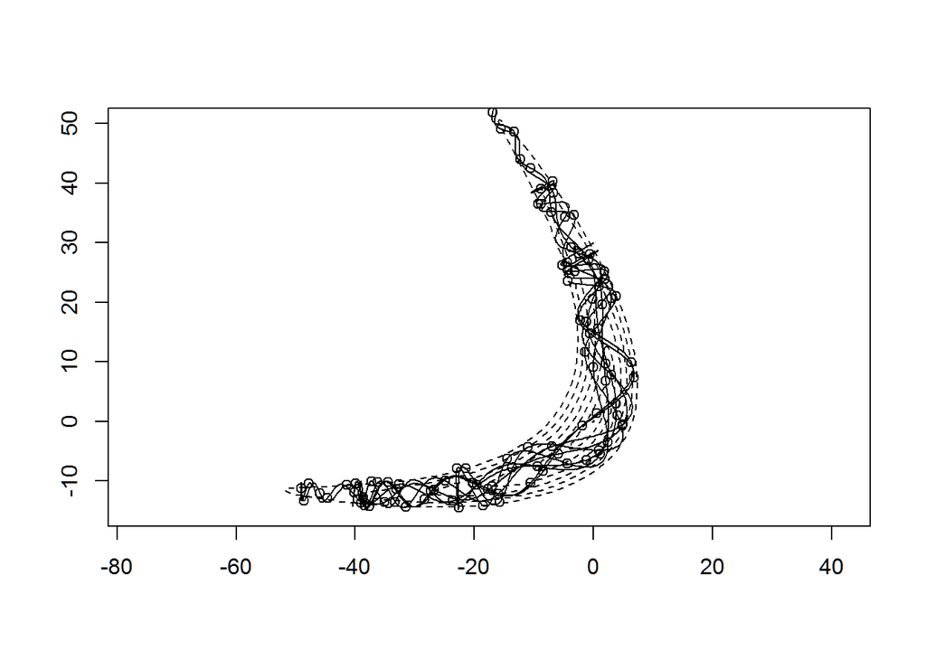

```
## Cumulative squared energy disparity: 0.09633346
```

```r
{
  plot(fc(c(.001,seq(1,6)^2)),type = 'l', lty = 2, ylim = c(-15,50), xlim=c(-50,15), asp = 1, xlab = '',ylab = '')
  stepsize <- .1
  steps <- 20
  pch <- 21
  cex = 1.3
  col  <- 'black'

  for(imax in c(5,10,40,100)){
    x <- c(0,30)
    m <- c(0,0)
    ac <- 0
    plot(fc(c(.001,seq(1,6)^2)),type = 'l', lty = 2, ylim = c(-15,50), xlim=c(-50,15), asp = 1, xlab = '',ylab = '')
    for(i in 1:imax) {
      ret <- hamTraj(x,m, f, fg, stepsize = stepsize, steps = steps)
      lines(ret$x,col=col)
      ac <- ac + (ret$a-1)^2
      points(tail(ret$x,1), pch = pch, col = col)
      x <- c(tail(ret$x,1))
      m <- c(tail(ret$m,1))
    }
  }
  cat("Cumulative squared energy disparity:", ac,'\n' )
}
```

## Exploring different trajectories

### Dropping

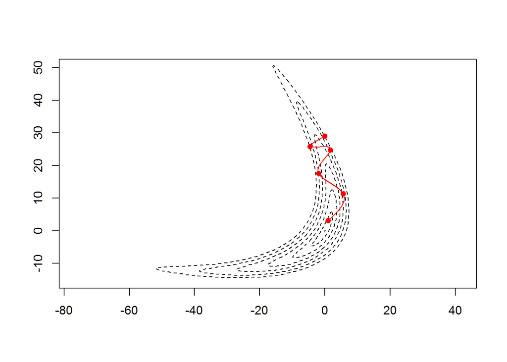

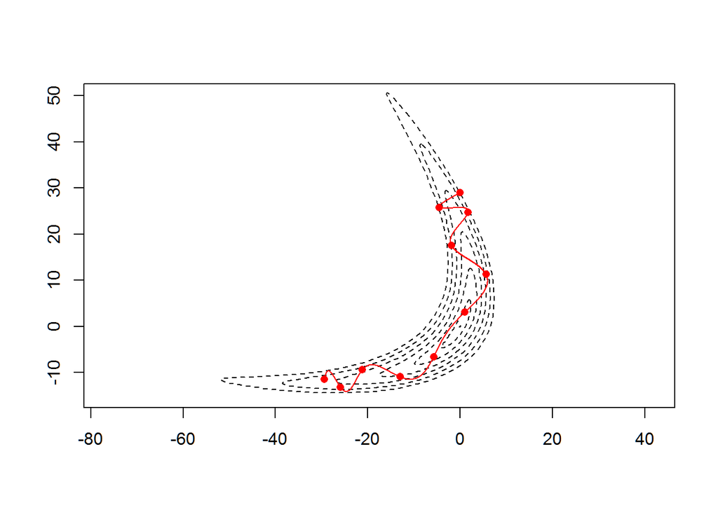

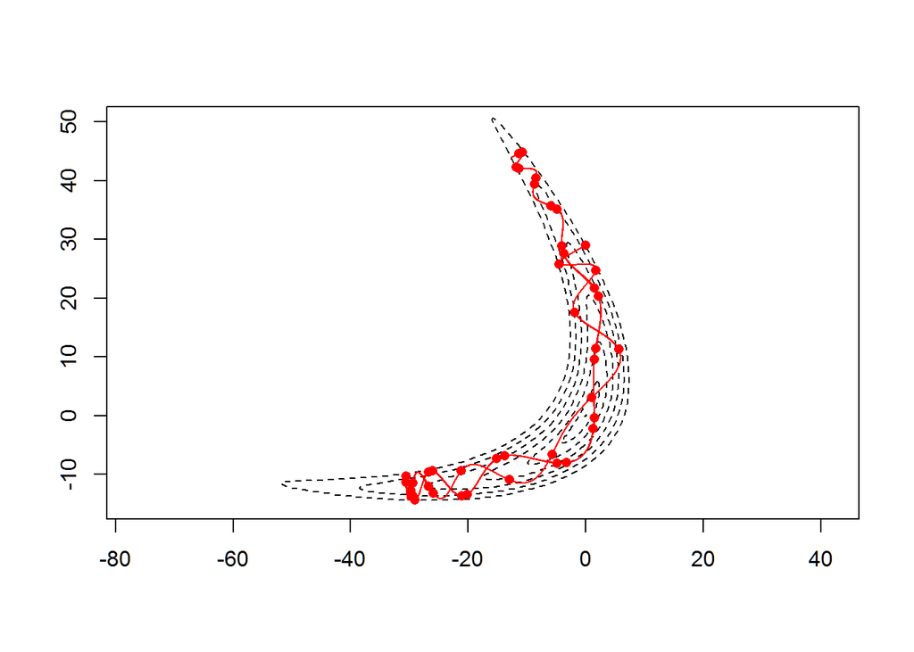

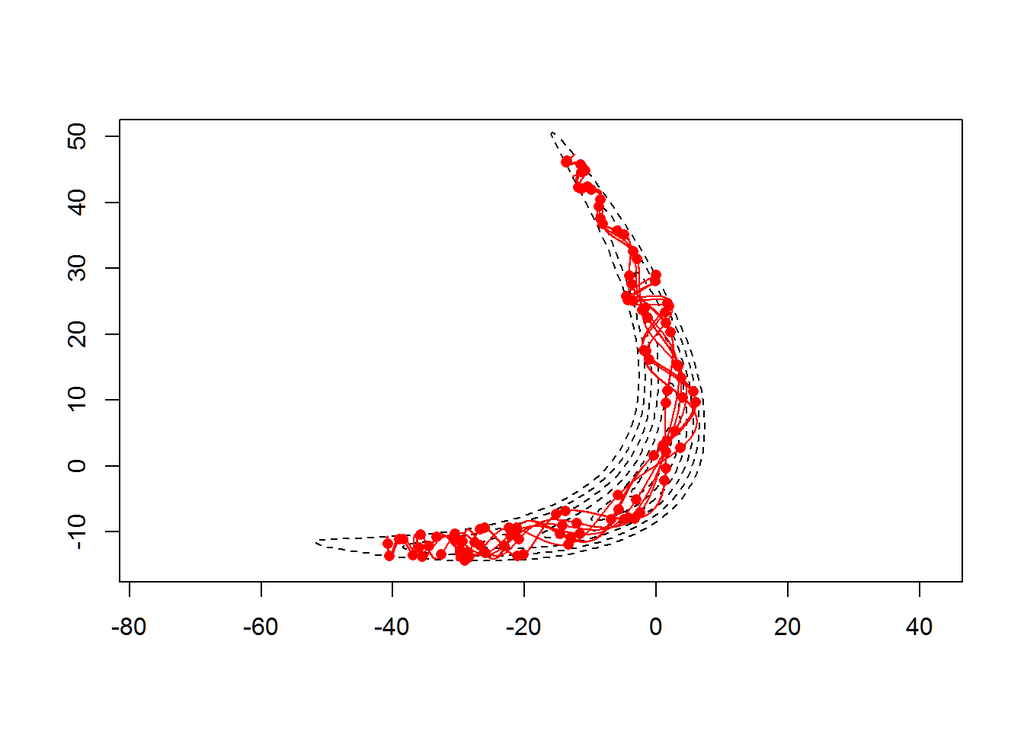

```r
{
  stepsize <- .001
  steps <- 2000
  pch <- 16
  cex = 1
  col  <- 'red'

  for( imax in c(5,10,40,100)){
    plot(fc(c(.001,seq(1,6)^2)),type = 'l', lty = 2, ylim = c(-15,50), xlim=c(-50,15),asp=1,, xlab = '',ylab = '')
    x <- c(0,29)
    m <- c(0,0)
    for(i in 1:imax) {
      points(rbind(x), col = col, pch = pch)
      ret <- hamTraj(x,m, f, fg, stepsize = stepsize, steps = steps)
      lines(ret$x,col=col)
      points(tail(ret$x,1), pch = pch, col = col)
      x <- c(tail(ret$x,1))
      m <- c(tail(ret$m,1))
    }
  }
}
```

Stepsizes of 0.01 and 0.001 yielded the same trajectory (visually) but using 0.1 produced divergence towards the end of the trajectory.

### Banana-shaped orbit

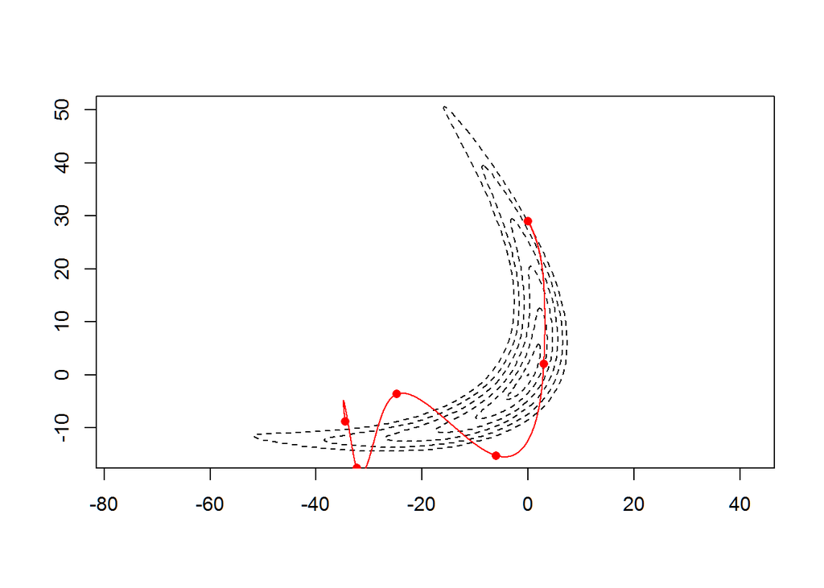

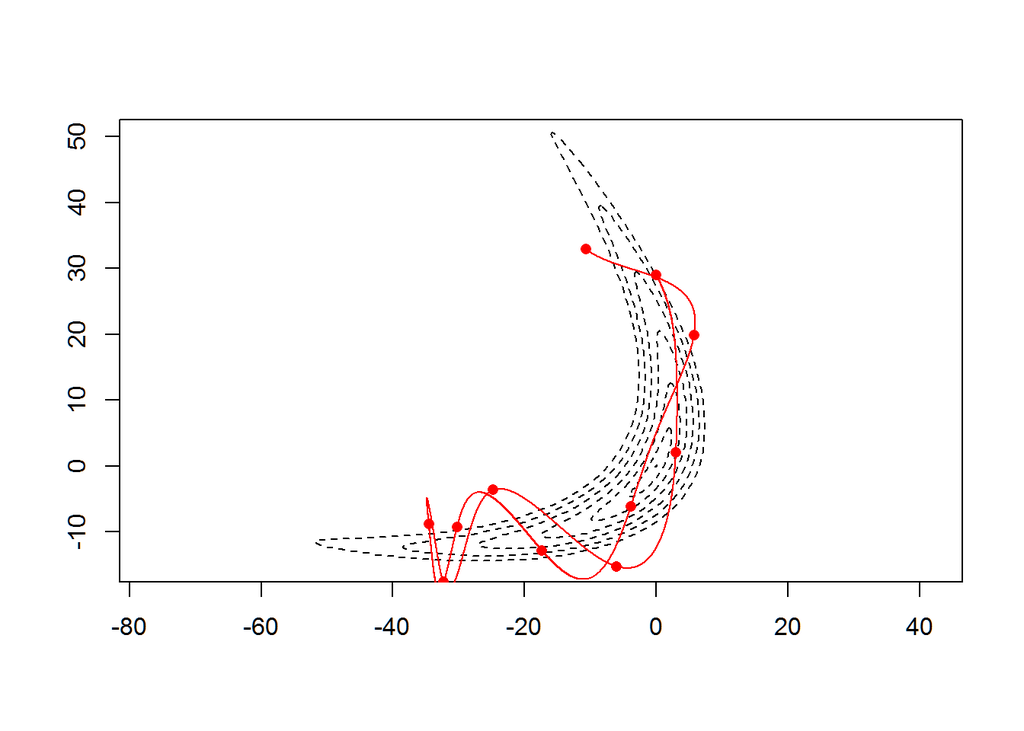

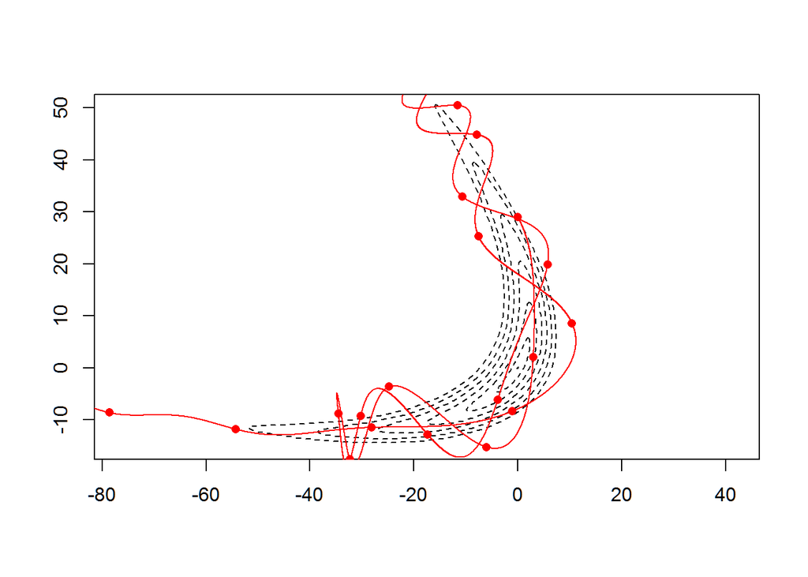

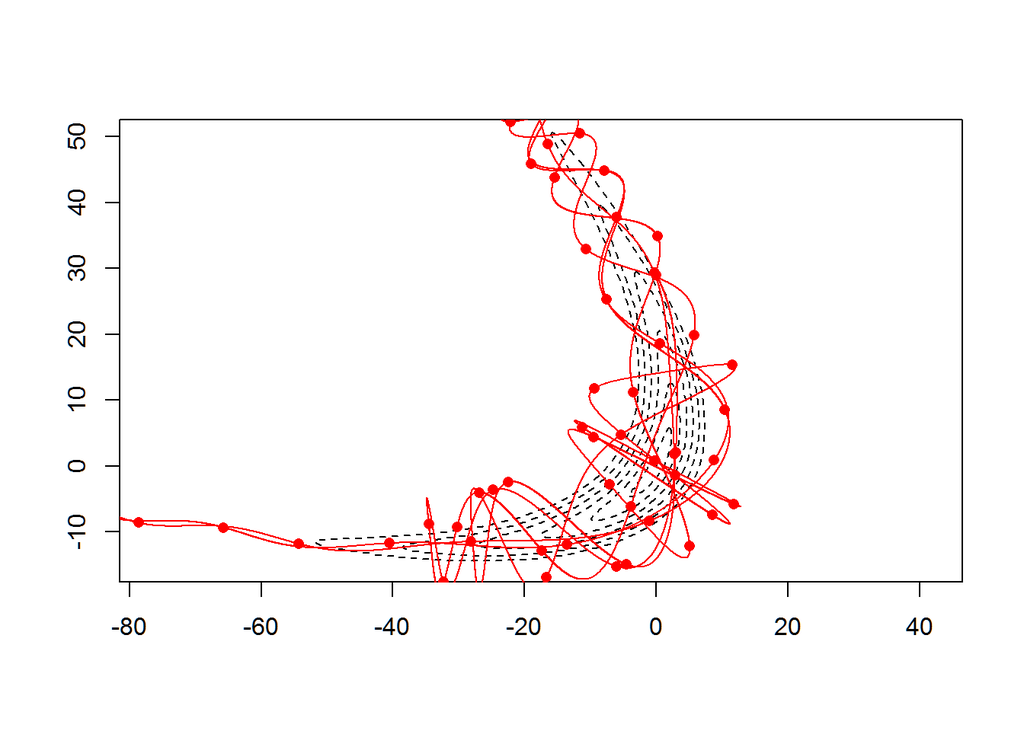

```r
{
  stepsize <- .001
  steps <- 2000
  pch <- 16
  cex = 1
  col  <- 'red'

  for( imax in c(5,10,40,100)){
    plot(fc(c(.001,seq(1,6)^2)),type = 'l', lty = 2, ylim = c(-15,50), xlim=c(-50,15),asp=1, xlab = '',ylab = '')
    x <- c(0,29)
    m <- 1.5* c(1,-1)*rev(fg(x))
    for(i in 1:imax) {
      points(rbind(x), col = col, pch = pch)
      ret <- hamTraj(x,m, f, fg, stepsize = stepsize, steps = steps)
      lines(ret$x,col=col)
      points(tail(ret$x,1), pch = pch, col = col)
      x <- c(tail(ret$x,1))
      m <- c(tail(ret$m,1))
    }
  }
}
```

## Trajectories in elliptical bowl

```r
Sigma <- cbind( c(36,0), c(0,1))
f <- f_gen(0, 0, Sigma)
fg <- f_grad_gen(0, 0, Sigma)
fc <- f_contour_gen(0, 0, Sigma)
```

### Dropping

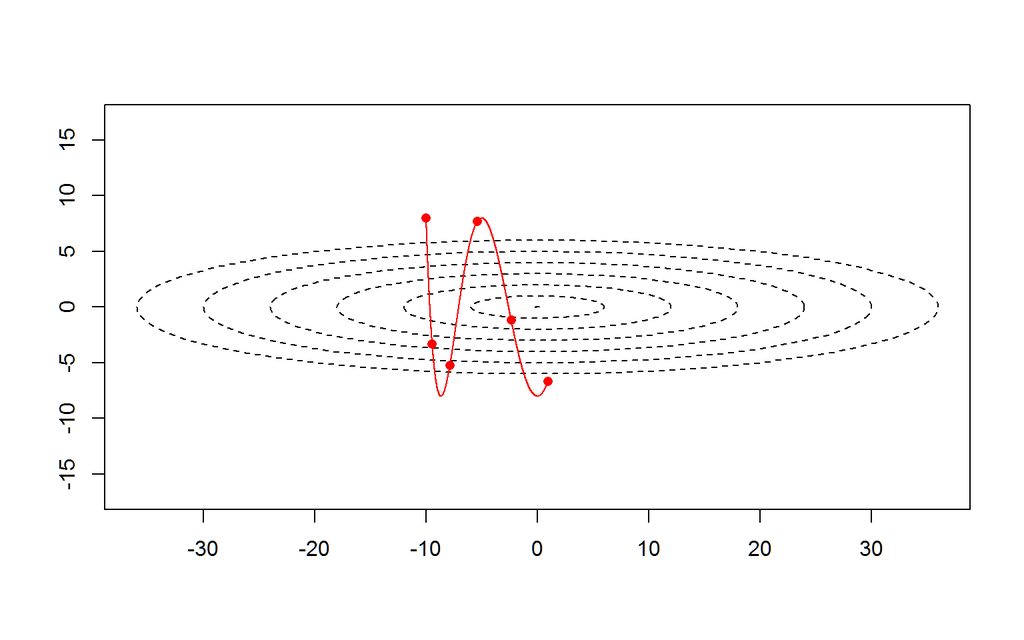

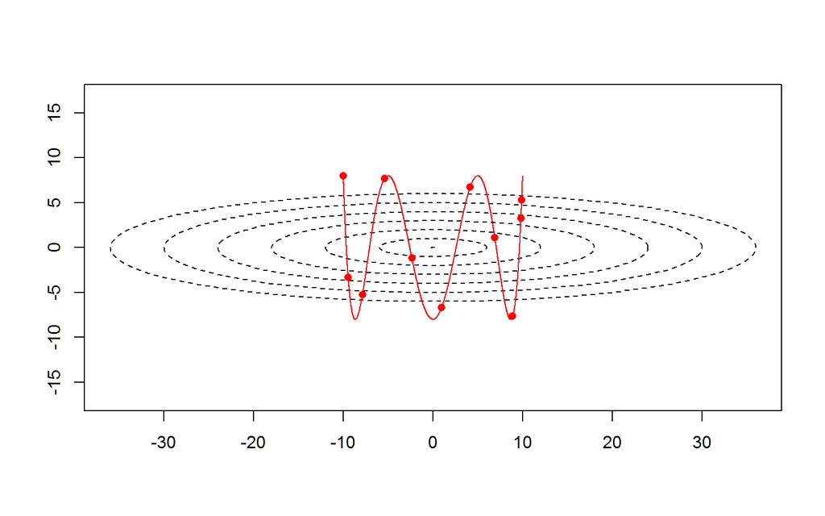

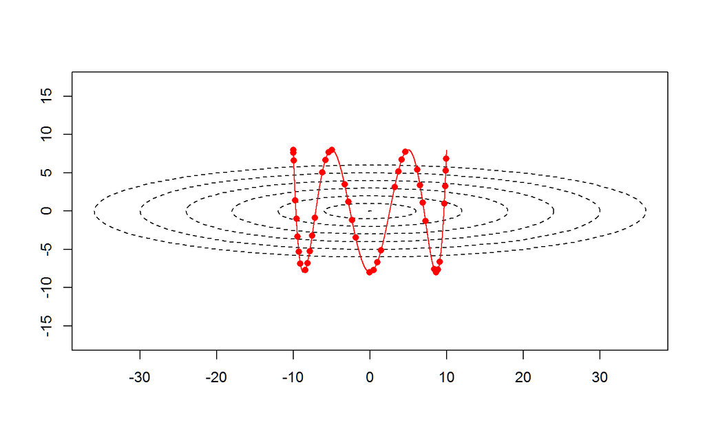

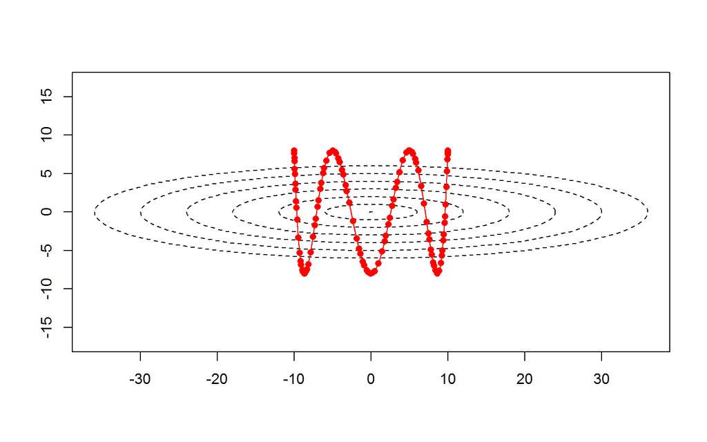

```r
# windows( 16, 10)
{
  stepsize <- .001
  steps <- 2000
  pch <- 16
  cex = 1
  col  <- 'red'

  for( imax in c(5,10,40,100)){
    plot(fc(c(.001,seq(1,6)^2)),type = 'l', lty = 2, ylim = c(-10,10),asp=1, xlab = '',ylab = '')
    x <- c(-10,8)
    m <- c(0,0)
    for(i in 1:imax) {
      points(rbind(x), col = col, pch = pch)
      ret <- hamTraj(x,m, f, fg, stepsize = stepsize, steps = steps)
      lines(ret$x,col=col)
      points(tail(ret$x,1), pch = pch, col = col)
      x <- c(tail(ret$x,1))
      m <- c(tail(ret$m,1))
    }
  }
}
```

### Orbit?

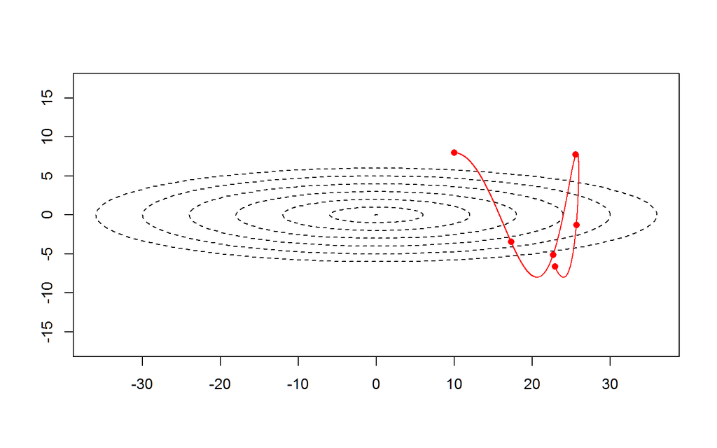

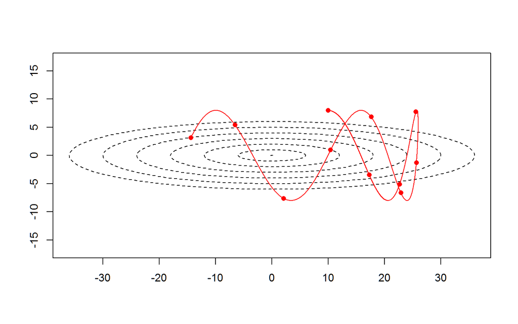

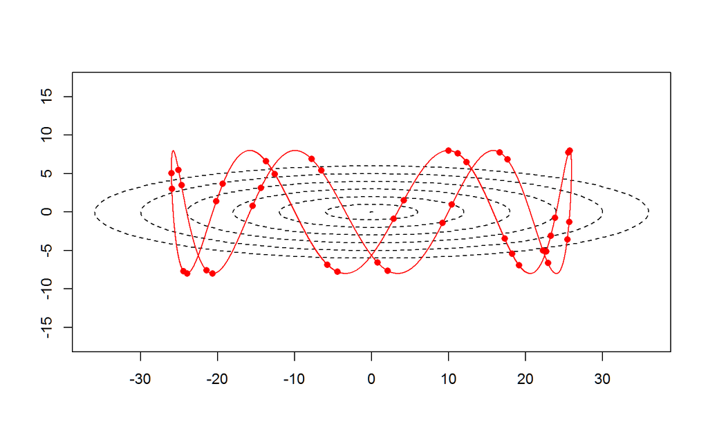

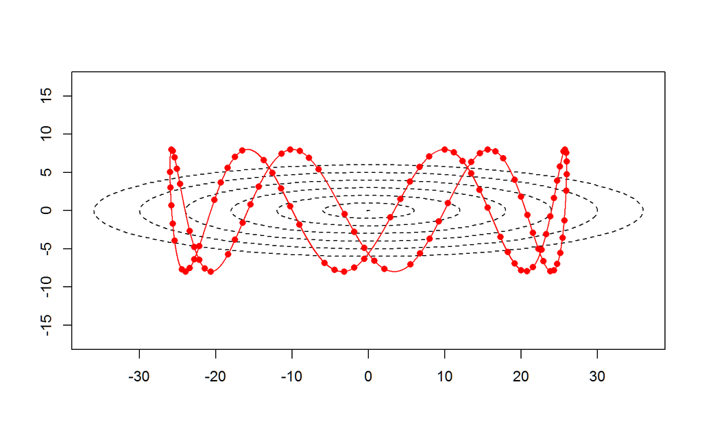

```r
# windows( 16, 10)
{
  stepsize <- .001
  steps <- 2000
  pch <- 16
  cex = 1
  col  <- 'red'

  for( imax in c(5,10,40,100)){
    plot(fc(c(.001,seq(1,6)^2)),type = 'l', lty = 2, ylim = c(-10,10),asp=1, xlab = '',ylab = '')
    x <- c(10,8)
    m <- .5* c(1,-1)*rev(fg(x))
    for(i in 1:imax) {
      points(rbind(x), col = col, pch = pch)
      ret <- hamTraj(x,m, f, fg, stepsize = stepsize, steps = steps)
      lines(ret$x,col=col)
      points(tail(ret$x,1), pch = pch, col = col)
      x <- c(tail(ret$x,1))
      m <- c(tail(ret$m,1))
    }
  }
}
```

## Trajectories in spherical bowl

```r
Sigma <- cbind( c(1,0), c(0,1))
f <- f_gen(0, 0, Sigma)
fg <- f_grad_gen(0, 0, Sigma)
fc <- f_contour_gen(0, 0, Sigma)
```

### Dropping

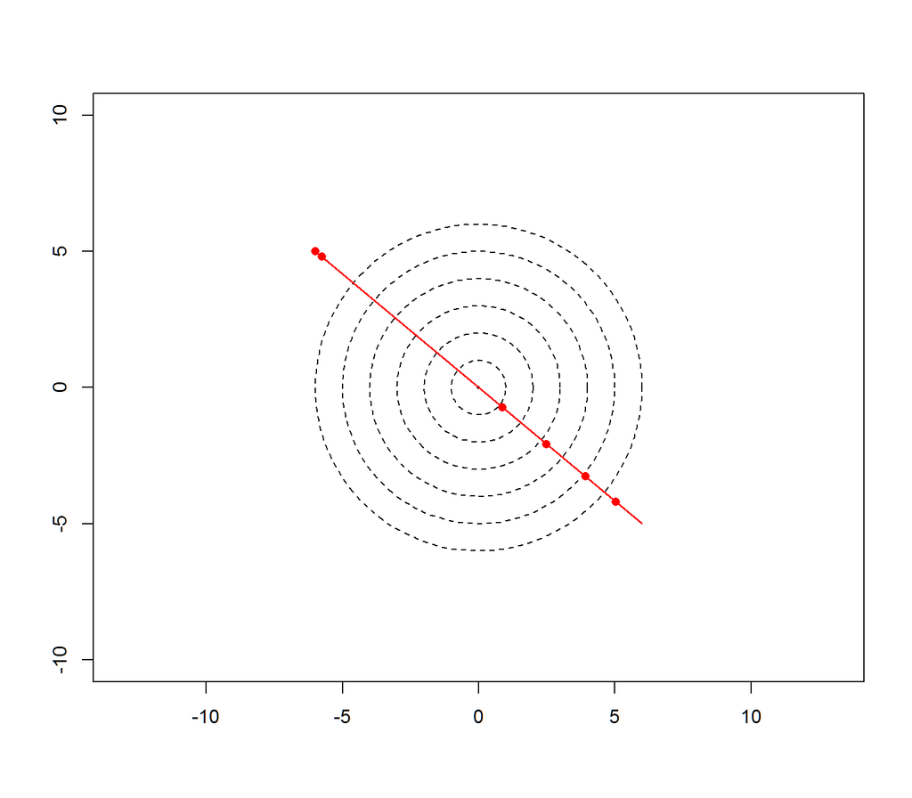

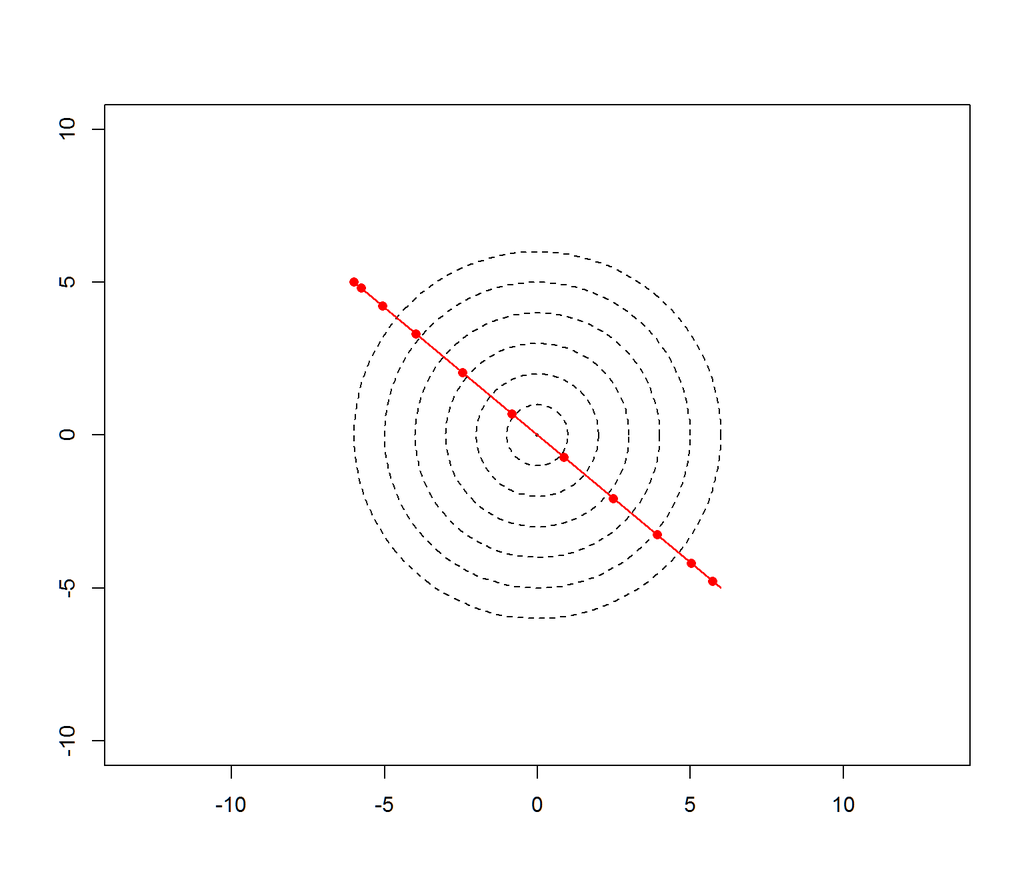

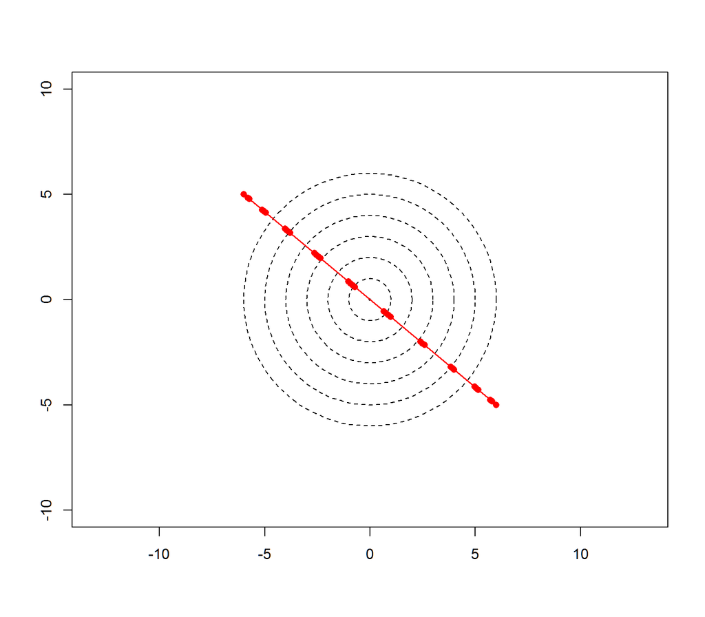

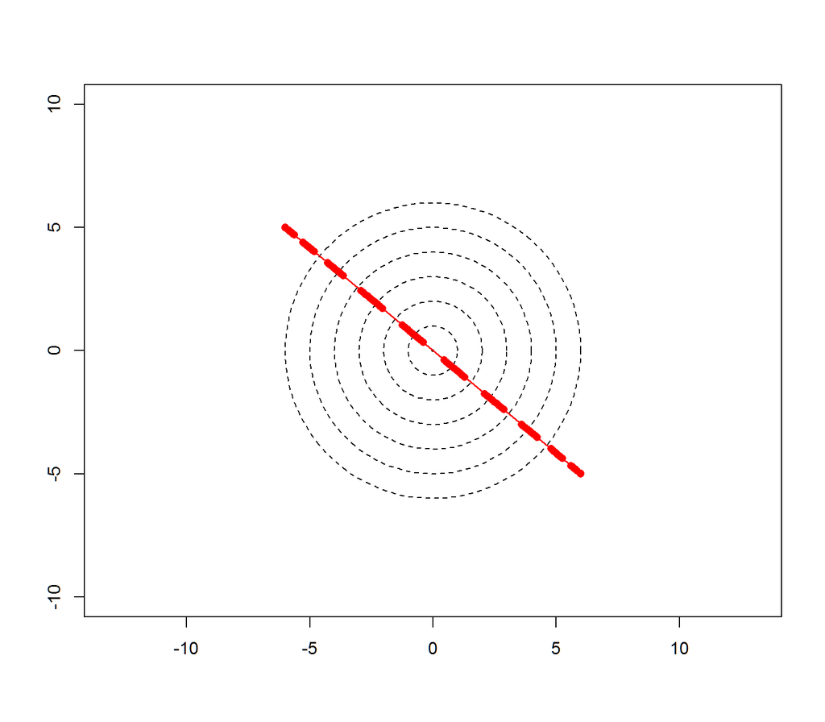

```r
# windows( 16, 10)
{
  stepsize <- .001
  steps <- 2000
  pch <- 16
  cex = 1
  col  <- 'red'

  for( imax in c(5,10,40,100)){
    plot(fc(c(.001,seq(1,6)^2)),type = 'l', lty = 2, ylim = c(-10,10),asp=1, xlab = '',ylab = '')
    x <- c(-6,5)
    m <- c(0,0)
    for(i in 1:imax) {
      points(rbind(x), col = col, pch = pch)
      ret <- hamTraj(x,m, f, fg, stepsize = stepsize, steps = steps)
      lines(ret$x,col=col)
      points(tail(ret$x,1), pch = pch, col = col)
      x <- c(tail(ret$x,1))
      m <- c(tail(ret$m,1))
    }
  }
}
```